# A survival regression model for left-censored PAH4 data in smoked black tea

Truong Ngan Giang

2025-11-01

## Summary

This project aims to create a survival regression model for left-censored data used to derive a best-fit mean estimate for data sets with non-detects or non-quantifications. The developed model will then be compared to traditional methods, such as substituted with ND/NQ exclusion, LOD/2 and zero substitutes.

## Method Explanation

Censored data (NDs/NQs) contain valuable information but are often mishandled. Naive methods (LOD/2, zero substitution) introduce bias, while survival analysis properly uses all available information to give unbiased estimates. The censored data is handled as intervals, from lower bound to upper bound. ND values are considered (0, LOD) while NQ values are (0, LOQ).

## Data source

This model utilizes PAH4 data from a study about smoked black tea by Girelli et al., 2017.

```r
# Black tea data with NA for NDs/NQs, from studies by Girelli et al. (2017)
Black <- data.frame(
  Sample = 1:10,
  conc_left = c(NA, 2.7, NA, NA, NA, NA, NA, 1.5, 1.6, 1.5),  # NA for NDs/NQs
  conc_right = c(0.8, 2.7, 0.4, 0.8, 0.8, 0.4, 0.8, 1.5, 1.6, 1.5)  # LOD/LOQ for NDs/NQs
)

# Display the data
knitr::kable(Black,
             caption = "Table 1: PAH4 data of 10 smoked black tea samples (Girelli et al., 2017)",
             col.names = c("Sample no", "Lower bound (μg/kg)", "Upper bound (μg/kg)"))
```

Table 1: PAH4 data of 10 smoked black tea samples (Girelli et al., 2017)

| Sample no | Lower bound (μg/kg) | Upper bound (μg/kg) |
| --- | --- | --- |
| 1 | NA | 0.8 |
| 2 | 2.7 | 2.7 |
| 3 | NA | 0.4 |
| 4 | NA | 0.8 |
| 5 | NA | 0.8 |
| 6 | NA | 0.4 |
| 7 | NA | 0.8 |
| 8 | 1.5 | 1.5 |
| 9 | 1.6 | 1.6 |
| 10 | 1.5 | 1.5 |

## Survival analysis

```r
# Fit the interval-censored lognormal model
modelBlack <- survreg(Surv(conc_left, conc_right, type = "interval2") ~ 1,
                      data = Black, dist = "lognormal")

# Model summary
tidy_model <- tidy(modelBlack)
kable(tidy_model, caption = "Interval-censored lognormal model (Black data)")
```

Interval-censored lognormal model (Black data)

| term | estimate | std.error | statistic | p.value |
| --- | --- | --- | --- | --- |
| (Intercept) | -0.6748380 | 0.5329294 | -1.2662804 | 0.2054127 |
| Log(scale) | 0.1792007 | 0.4110639 | 0.4359437 | 0.6628776 |

```r
# Extract parameters
log_mean <- coef(modelBlack)  # Mean on log scale
log_sd <- modelBlack$scale    # SD on log scale

# Transform to original scale
geometric_mean <- exp(log_mean)                     # Median (geometric mean)
arithmetic_mean <- exp(log_mean + (log_sd^2)/2)     # Arithmetic mean
geometric_sd <- exp(log_sd)                         # Geometric SD

# Get confidence intervals
conf_log <- confint(modelBlack)        # On log scale
conf_geom <- exp(conf_log)             # On original scale

# Create results table
black_results <- data.frame(
  Parameter = c("Log Mean", "Log SD",
                "Geometric Mean (Median)", "Arithmetic Mean",
                "Geometric SD"),
  Estimate = c(round(log_mean, 3), round(log_sd, 3),
               round(geometric_mean, 3), round(arithmetic_mean, 3),
               round(geometric_sd, 3)),
  `95% CI Lower` = c(round(conf_log[1], 3), NA,
                     round(conf_geom[1], 3), NA, NA),
  `95% CI Upper` = c(round(conf_log[2], 3), NA,
                     round(conf_geom[2], 3), NA, NA),
  Units = c("log(μg/kg)", "log(μg/kg)", "μg/kg", "μg/kg", "multiplicative factor")
)

knitr::kable(black_results,
             caption = "Table 2: Parameter estimates",
             col.names = c ("Parameter", "Estimate", "95% CI Lower", "95% CI Upper", "Units"))
```

Table 2: Parameter estimates

| Parameter | Estimate | 95% CI Lower | 95% CI Upper | Units |
| --- | --- | --- | --- | --- |
| Log Mean | -0.675 | -1.719 | 0.370 | log(μg/kg) |
| Log SD | 1.196 | NA | NA | log(μg/kg) |
| Geometric Mean (Median) | 0.509 | 0.179 | 1.447 | μg/kg |
| Arithmetic Mean | 1.042 | NA | NA | μg/kg |
| Geometric SD | 3.308 | NA | NA | multiplicative factor |

## Comparison with naive methods

```r
# Compare with naive ethods

# Method 1: Use only detects (ignores NDs/NQs)
mean_detects_only <- mean(Black$conc_left, na.rm = TRUE)

# Method 2: LOD/2 substitution
conc_LOD2 <- ifelse(is.na(Black$conc_left), Black$conc_right/2, Black$conc_left)
mean_LOD2 <- mean(conc_LOD2)

# Method 3: Zero substitution (worst case)
conc_zero <- ifelse(is.na(Black$conc_left), 0, Black$conc_left)
mean_zero <- mean(conc_zero)

comparison <- data.frame(
  Method = c("Interval-Censored Survival",
             "Detects Only (excludes NDs/NQs)",
             "LOD/2 Substitution",
             "Zero Substitution"),
  Estimate = round(c(arithmetic_mean, mean_detects_only, mean_LOD2, mean_zero), 3),
  `% Difference from Recommended Method` = round(c(0,
                                         (mean_detects_only - arithmetic_mean)/arithmetic_mean*100,
                                         (mean_LOD2 - arithmetic_mean)/arithmetic_mean*100,
                                         (mean_zero - arithmetic_mean)/arithmetic_mean*100), 1)
)
# Create and display formatted table
knitr::kable(
  comparison,
  caption = "Table 3: Comparison of Different Handling Methods for Censored Data",
  col.names = c("Method", "Estimate (μg/kg)", "% Difference from Recommended Method")
)
```

Table 3: Comparison of Different Handling Methods for Censored Data

| Method | Estimate (μg/kg) | % Difference from Recommended Method |
| --- | --- | --- |
| Interval-Censored Survival | 1.042 | 0.0 |
| Detects Only (excludes NDs/NQs) | 1.825 | 75.2 |
| LOD/2 Substitution | 0.930 | -10.7 |
| Zero Substitution | 0.730 | -29.9 |

**Interpretation:**

1. Detects-only gives the highest estimate (+75% difference), which means this method is likely overestimating the mean value.  
2. The zero substitution method may underestimate the mean, demonstrated by the -30% differences to the recommended approach.  
3. LOD/2 shows intermediate difference (-10.7), but still arbitrary.

## Visualization

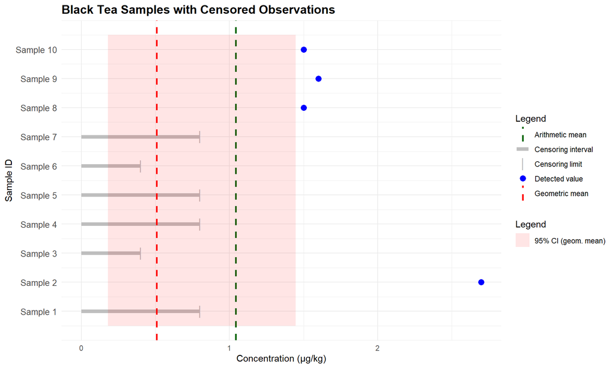

Figure 1: Distribution of Censored Data in Black tea samples

```r
# Add Sample ID to Black
Black$Sample <- 1:nrow(Black)

# Create a visualization with mapped aesthetics for legend
p <- ggplot() +
  # Censoring intervals (horizontal segments)
  geom_segment(data = Black[is.na(Black$conc_left), ],
               aes(x = 0, xend = conc_right, y = Sample, yend = Sample,
                   color = "Censoring interval"), linewidth = 2) +
  # Censoring limits (vertical ticks)
  geom_point(data = Black[is.na(Black$conc_left), ],
             aes(x = conc_right, y = Sample, color = "Censoring limit"),
             shape = "|", size = 5) +
  # Detected values
  geom_point(data = Black[!is.na(Black$conc_left), ],
             aes(x = conc_left, y = Sample, color = "Detected value"),
             shape = 19, size = 3) +
  # Fitted geometric mean
  geom_vline(aes(xintercept = geometric_mean, color = "Geometric mean"),
             linetype = "dashed", linewidth = 1) +
  # Fitted arithmetic mean
  geom_vline(aes(xintercept = arithmetic_mean, color = "Arithmetic mean"),
             linetype = "dashed", linewidth = 1) +
  # Confidence interval
  geom_rect(aes(xmin = conf_geom[1], xmax = conf_geom[2],
                ymin = 0.5, ymax = 10.5, fill = "95% CI (geom. mean)"),
            alpha = 0.1) +
  labs(
    title = "Black Tea Samples with Censored Observations",
    x = "Concentration (μg/kg)",
    y = "Sample ID",
    color = "Legend",   # legend title for colors
    fill = "Legend"     # legend title for fills
  ) +
  theme_minimal() +
  theme(
    plot.title = element_text(face = "bold", size = 14),
    axis.text.y = element_text(size = 10)
  ) +
  scale_y_continuous(breaks = 1:10, labels = paste("Sample", 1:10)) +
  scale_color_manual(values = c(
    "Censoring interval" = "gray",
    "Censoring limit" = "gray",
    "Detected value" = "blue",
    "Geometric mean" = "red",
    "Arithmetic mean" = "darkgreen"
  )) +
  scale_fill_manual(values = c("95% CI (geom. mean)" = "red"))

print(p)
```

## Limitation

This analysis compares method disagreement rather than true bias. True bias assessment would require:  
1. Known true population values (unavailable in this data set)  
2. Simulation studies with controlled data generation

**Future improvement:** A simulation study could validate which method is least biased under similar censoring patterns.

## Conclusion

This analysis demonstrates that:

- Uses all available information without arbitrary substitutions

- Provides uncertainty quantification via confidence intervals

- Is recommended by statistical guidelines for censored data

## References

Girelli, A. M., Apriceno, A., Tarola, A. M., & Tortora, F. (2017). Determination of Polycyclic Aromatic Hydrocarbons in Tea Infusions Samples by High Performance Liquid Chromatography with Fluorimetric Detection. Journal of Food Quality, 2017, 1–7. https://doi.org/10.1155/2017/1076876